# Predicting weightlifting technique using data from wearable activity tracking devices

Steve Scicluna

25 April 2019

### **Synopsis**

Using devices such as Jawbone Up, Nike FuelBand, and Fitbit, it is now possible to collect a large amount of data about personal activity relatively inexpensively. These devices are part of the “quantified self movement” - a group of enthusiasts who take measurements about themselves regularly to improve their health, to find patterns in their behavior, or because they are tech geeks. One thing that people regularly do is quantify how much of a particular activity they do, but they rarely quantify **how well** they do it.

In this project, I shall investigate activity tracker data from six male participants aged between 20 and 28 years, with limited weightlifting experience. These participants were asked to perform one set of ten repetitions of the Unilateral Dumbbell Biceps Curl using a 1.25 kg dumbbell in five different fashions, comprising the correct technique and four common technique errors as follows:

1. exactly according to the specification (Class A)
2. throwing the elbows to the front (Class B)
3. lifting the dumbbell only halfway (Class C)
4. lowering the dumbbell only halfway (Class D)
5. throwing the hips to the front (Class E).

This data was sourced from Velloso, E., Bulling, A., Gellersen, H., Ugulino, W., and Fuks, H. **Qualitative Activity Recognition of Weight Lifting Exercises**, *Proceedings of 4th International Conference in Cooperation with SIGCHI (Augmented Human ’13)*, Stuttgart, Germany: ACM SIGCHI, 2013. (http://groupware.les.inf.puc-rio.br/har#wle_paper_section)

I shall undertake two types of data analysis to investigate the degree of accuracy with which predictor variables can predict whether a Unilateral Dumbbell Biceps Curl is being performed correctly, and if not, which common error is being made. These are:

1. Random Forest
2. Decision Trees

The more accurate of these prediction models shall be used to predict whether a Unilateral Dumbbell Biceps Curl is being performed correctly, and if not, which common error is being made, using the test dataset.

### **Load software and data**

The following block of R code shall:

1. load a series of R packages
2. download the activity tracker data in the form of two .csv files (training and testing) from a web address and read the data into R
3. partition the training dataset into a training dataset (70%) and a validation dataset (30%)
4. remove variables that have near zero variability, are mostly blank or NA, and have no predictive value (e.g. identification numbers, timestamps etc.)

```r
# Load required software packages.
        library(rpart)
        library(caret)
        library(randomForest)
```

```r
# Load required data
        training <- read.csv("https://d396qusza40orc.cloudfront.net/predmachlearn/pml-training.csv")
        testing <- read.csv("https://d396qusza40orc.cloudfront.net/predmachlearn/pml-testing.csv")

# Partition training dataset into a 70:30 training:validation dataset
        inTrain  <- createDataPartition(training$classe, p = 0.7, list = FALSE)
        trainset <- training[inTrain, ]
        validset <- training[-inTrain, ]

# Remove variables with near zero variability i.e. poor predictors
        nzv <- nearZeroVar(trainset)
        trainset <- trainset[, -nzv]
        validset <- validset[, -nzv]

# Remove mostly blank or NA variables
        mostNA <- sapply(trainset, function(x) mean(is.na(x))) > 0.90
        trainset <- trainset[, mostNA == FALSE]
        validset <- validset[, mostNA == FALSE]

# Remove first six columns - identification, timestamp etc.
        trainset <- trainset[, -(1:6)]
        validset <- validset[, -(1:6)]

# Check dataset dimensions
        dim(trainset)
```

```
## [1] 13737    53
```

```r
        dim(validset)
```

```
## [1] 5885   53
```

### **Prediction models**

This section shall compare the **Random Forest** and **Decision Tree** prediction models using the same training and validation datasets.

#### **Random Forest**

```r
# Random Forest model
        rfmodel <- randomForest(classe ~ ., data = trainset, ntree = 500)
        rfmodel
```

```
##
## Call:
##  randomForest(formula = classe ~ ., data = trainset, ntree = 500)
##                Type of random forest: classification
##                      Number of trees: 500
## No. of variables tried at each split: 7
##
##         OOB estimate of  error rate: 0.47%
## Confusion matrix:
##      A    B    C    D    E  class.error
## A 3905    0    0    0    1 0.0002560164
## B   12 2643    3    0    0 0.0056433409
## C    0   15 2379    2    0 0.0070951586
## D    0    0   23 2226    3 0.0115452931
## E    0    0    2    3 2520 0.0019801980
```

```r
# Predict against validation dataset
        rfpredict <- predict(rfmodel, validset, type = "class")
        rfcm <- confusionMatrix(rfpredict, validset$classe)
        rfcm
```

```
## Confusion Matrix and Statistics
##
##           Reference
## Prediction    A    B    C    D    E
##          A 1670    6    0    0    0
##          B    4 1128    5    0    0
##          C    0    5 1021   10    0
##          D    0    0    0  954    7
##          E    0    0    0    0 1075
##
## Overall Statistics
##
##                Accuracy : 0.9937
##                  95% CI : (0.9913, 0.9956)
##     No Information Rate : 0.2845
##     P-Value [Acc > NIR] : < 2.2e-16
##
##                   Kappa : 0.992
##
##  Mcnemar's Test P-Value : NA
##
## Statistics by Class:
##
##                      Class: A Class: B Class: C Class: D Class: E
## Sensitivity            0.9976   0.9903   0.9951   0.9896   0.9935
## Specificity            0.9986   0.9981   0.9969   0.9986   1.0000
## Pos Pred Value         0.9964   0.9921   0.9855   0.9927   1.0000
## Neg Pred Value         0.9990   0.9977   0.9990   0.9980   0.9985
## Prevalence             0.2845   0.1935   0.1743   0.1638   0.1839
## Detection Rate         0.2838   0.1917   0.1735   0.1621   0.1827
## Detection Prevalence   0.2848   0.1932   0.1760   0.1633   0.1827
## Balanced Accuracy      0.9981   0.9942   0.9960   0.9941   0.9968
```

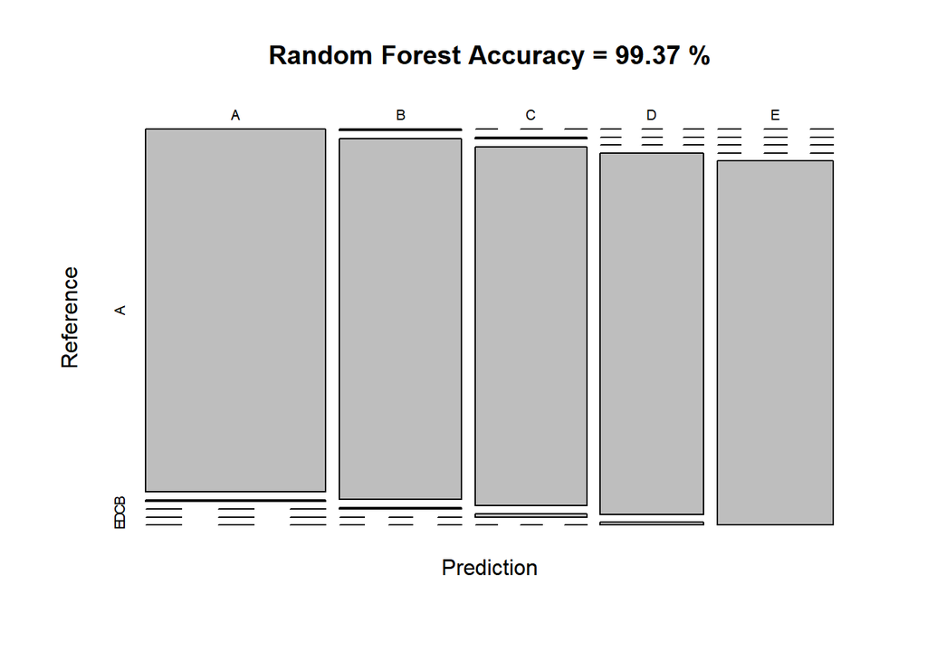

```r
# Plot confusion matrix results
        plot(rfcm$table, main = paste("Random Forest Accuracy =", (100*round(rfcm$overall['Accuracy'], 4)),"%"))
```

#### **Decision Tree**

```r
# Decision Tree model
        dtmodel <- rpart(classe ~ ., data = trainset, method = "class")
        dtmodel
```

```
## n= 13737
##
## node), split, n, loss, yval, (yprob)
##       * denotes terminal node
##
##    1) root 13737 9831 A (0.28 0.19 0.17 0.16 0.18)
##      2) roll_belt< 130.5 12593 8696 A (0.31 0.21 0.19 0.18 0.11)
##        4) pitch_forearm< -33.95 1095    5 A (1 0.0046 0 0 0) *
##        5) pitch_forearm>=-33.95 11498 8691 A (0.24 0.23 0.21 0.2 0.12)
##         10) roll_forearm< 124.5 7384 4848 A (0.34 0.24 0.15 0.19 0.073)
##           20) magnet_dumbbell_y< 426.5 5972 3513 A (0.41 0.18 0.18 0.17 0.062)
##             40) magnet_dumbbell_z< -24.5 2101  700 A (0.67 0.21 0.015 0.079 0.03)
##               80) roll_forearm>=-136.5 1760  391 A (0.78 0.17 0.016 0.028 0.0074) *
##               81) roll_forearm< -136.5 341  202 B (0.094 0.41 0.0088 0.34 0.15) *
##             41) magnet_dumbbell_z>=-24.5 3871 2813 A (0.27 0.17 0.27 0.22 0.079)
##               82) yaw_belt>=169.5 468   57 A (0.88 0.056 0 0.064 0.0021) *
##               83) yaw_belt< 169.5 3403 2373 C (0.19 0.18 0.3 0.24 0.089)
##                166) pitch_belt< -43.15 336   52 B (0.012 0.85 0.074 0.042 0.027) *
##                167) pitch_belt>=-43.15 3067 2062 C (0.21 0.11 0.33 0.26 0.096)
##                  334) accel_dumbbell_y>=-40.5 2635 1860 D (0.24 0.12 0.24 0.29 0.11)
##                    668) roll_belt>=125.5 654  276 C (0.38 0.029 0.58 0.014 0)
##                     1336) magnet_belt_z< -325.5 203    0 A (1 0 0 0 0) *
##                     1337) magnet_belt_z>=-325.5 451   73 C (0.1 0.042 0.84 0.02 0) *
##                    669) roll_belt< 125.5 1981 1215 D (0.2 0.15 0.13 0.39 0.14)
##                     1338) accel_dumbbell_z< 27.5 1438  806 D (0.26 0.092 0.17 0.44 0.037)
##                       2676) accel_forearm_x>=-80.5 765  427 A (0.44 0.12 0.15 0.23 0.055) *
##                       2677) accel_forearm_x< -80.5 673  219 D (0.052 0.059 0.2 0.67 0.016) *
##                     1339) accel_dumbbell_z>=27.5 543  313 E (0.029 0.29 0.0055 0.25 0.42)
##                       2678) roll_dumbbell< 36.19782 152   32 B (0.033 0.79 0.02 0.059 0.099) *
##                       2679) roll_dumbbell>=36.19782 391  176 E (0.028 0.1 0 0.32 0.55) *
##                  335) accel_dumbbell_y< -40.5 432   56 C (0.014 0.044 0.87 0.044 0.028) *
##           21) magnet_dumbbell_y>=426.5 1412  697 B (0.055 0.51 0.035 0.28 0.12)
##             42) total_accel_dumbbell>=5.5 875  246 B (0.088 0.72 0.057 0.0091 0.13) *
##             43) total_accel_dumbbell< 5.5 537  146 D (0 0.16 0 0.73 0.11) *
##         11) roll_forearm>=124.5 4114 2829 C (0.066 0.21 0.31 0.21 0.21)
##           22) magnet_dumbbell_y< 290.5 2131 1066 C (0.088 0.13 0.5 0.14 0.14)
##             44) magnet_dumbbell_z>=284.5 296  148 A (0.5 0.14 0.044 0.098 0.22) *
##             45) magnet_dumbbell_z< 284.5 1835  783 C (0.021 0.13 0.57 0.15 0.13) *
##           23) magnet_dumbbell_y>=290.5 1983 1406 B (0.042 0.29 0.11 0.28 0.28)
##             46) accel_forearm_x>=-102.5 1366  881 B (0.035 0.36 0.14 0.11 0.35)
##               92) roll_belt>=-0.85 1121  636 B (0.043 0.43 0.18 0.092 0.26) *
##               93) roll_belt< -0.85 245   50 E (0 0 0 0.2 0.8) *
##             47) accel_forearm_x< -102.5 617  219 D (0.058 0.15 0.036 0.65 0.11) *
##      3) roll_belt>=130.5 1144    9 E (0.0079 0 0 0 0.99) *
```

```r
# Predict against validation dataset
        dtpredict <- predict(dtmodel, validset, type = "class")
        dtcm <- confusionMatrix(dtpredict, validset$classe)
        dtcm
```

```
## Confusion Matrix and Statistics
##
##           Reference
## Prediction    A    B    C    D    E
##          A 1512  185  114  124   51
##          B   81  723  107  112  229
##          C   36  113  739  138   99
##          D   31   97   66  517   49
##          E   14   21    0   73  654
##
## Overall Statistics
##
##                Accuracy : 0.7043
##                  95% CI : (0.6925, 0.716)
##     No Information Rate : 0.2845
##     P-Value [Acc > NIR] : < 2.2e-16
##
##                   Kappa : 0.6231
##
##  Mcnemar's Test P-Value : < 2.2e-16
##
## Statistics by Class:
##
##                      Class: A Class: B Class: C Class: D Class: E
## Sensitivity            0.9032   0.6348   0.7203  0.53631   0.6044
## Specificity            0.8874   0.8885   0.9206  0.95062   0.9775
## Pos Pred Value         0.7613   0.5775   0.6569  0.68026   0.8583
## Neg Pred Value         0.9585   0.9102   0.9397  0.91278   0.9165
## Prevalence             0.2845   0.1935   0.1743  0.16381   0.1839
## Detection Rate         0.2569   0.1229   0.1256  0.08785   0.1111
## Detection Prevalence   0.3375   0.2127   0.1912  0.12914   0.1295
## Balanced Accuracy      0.8953   0.7617   0.8204  0.74346   0.7910
```

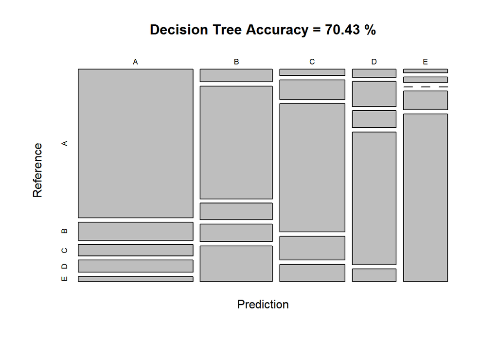

```r
# Plot confusion matrix results
        plot(dtcm$table, main = paste("Decision Tree Accuracy =", (100*round(dtcm$overall['Accuracy'], 4)),"%"))
```

### **Findings**

Out of sample error rates are measured by calculating **1 minus the Accuracy figure** that was calculated when validating the prediction model developed from the training dataset against the validation dataset. The Random Forest prediction model has a very high accuracy rate of **99.37%**, so the out of sample error rate is **0.63%**. The Decision Tree prediction model has a lower accuracy rate of **70.43%**, and therefore has a higher out of sample error rate of **29.57%**.

### **Conclusion**

This section shall apply the **Random Forest** prediction model to the testing dataset to predict a new **testing$classe** variable for each of the twenty observations in the testing dataset.

```r
#Predict against test dataset
        testing$classe <- predict(rfmodel, testing, type = "class")
        testing$classe
```

```
##  [1] B A B A A E D B A A B C B A E E A B B B
## Levels: A B C D E
```